# Probset performance measurements on slide 0020227

- Environment
  - Read in Xenium
  - Read in IPF Cell Atlas GSE136831
  - Normalize both datasets
- Comparison of raw counts between scRNA and Xenium
  - Zero-suppressed average expression
  - Zero-suppressed median expression
- Comparison of normalized counts between scRNA and Xenium
  - Zero-suppressed average normalized expression
  - Mix and match

This is a slide that was run in December 2023. The slide includes one section from the same block (the “good” block) done with the limited library on 0010972 that gave some decent data. One triangular piece is a scleroderma lung. The goal of this analysis is to look at components of probeset behavior and whether that can be predicted from single cell sequencing from reference datasets.

# Environment

```r
library(Seurat)
library(tidyverse)
```

## Read in Xenium

```r
ipf3.xen <- LoadXenium('output-XETG00143__0020227__Region_1__20231214__022306')
```

[output not shown]

## Read in IPF Cell Atlas GSE136831

```r
original.dir <- ('~/vcalab-files/datasets/GSE136831_IPF_Cell_Atlas/')
metadata <- read_tsv(paste0(original.dir,'GSE136831_AllCells.Samples.CellType.MetadataTable.txt.gz'))
metadata <- as.data.frame(metadata)
rownames(metadata) <- metadata$CellBarcode_Identity

features <- read_tsv(paste0(original.dir,'GSE136831_AllCells.GeneIDs.txt.gz'))
cells <- read_tsv(paste0(original.dir,'GSE136831_AllCells.cellBarcodes.txt.gz'), col_names = F)
counts <- Matrix::readMM(paste0(original.dir,'GSE136831_RawCounts_Sparse.mtx.gz'))
rownames(counts) <- features$HGNC_EnsemblAlt_GeneID
colnames(counts) <- cells$X1
```

```r
ipfatlas.cells <- CreateSeuratObject(counts=counts, meta.data=metadata)
rm(counts,cells,features,metadata)
gc()
```

```
##              used   (Mb) gc trigger    (Mb)   max used    (Mb)
## Ncells   33201204 1773.2  106306830  5677.4  106306830  5677.4
## Vcells 1150536909 8778.0 3670297946 28002.2 4285001700 32692.0
```

## Normalize both datasets

```r
ipf3.xen <- NormalizeData(ipf3.xen)
```

```
## Normalizing layer: counts
```

```r
ipfatlas.cells <- NormalizeData(ipfatlas.cells)
```

```
## Normalizing layer: counts
```

# Comparison of raw counts between scRNA and Xenium

```r
# limit analysis to probes that can be assessed
probes <- intersect(rownames(ipf3.xen), rownames(ipfatlas.cells))
```

```r
# Enable parallel processing - seurat does not play nice with parallel so all seurat processing should ideally be single-core
library(future)
plan(multisession, workers=6)
options(future.globals.maxSize = 104857600000000)
library(future.apply)
```

## Zero-suppressed average expression

```r
nonzeroaverages <- data.frame(gene=probes,
                              xeniumAvg=unlist(future_lapply(probes, function(symbol){
                                counts <- ipf3.xen[['Xenium']]$counts[symbol,]
                                nonzeroavg <- mean(counts[counts!=0])
                                return(nonzeroavg)
                                })),
                              ipfatlasAvg=unlist(future_lapply(probes, function(symbol){
                                counts <- ipfatlas.cells[['RNA']]$counts[symbol,]
                                nonzeroavg <- mean(counts[counts!=0])
                                return(nonzeroavg)
                              }))
)
```

[output not shown]

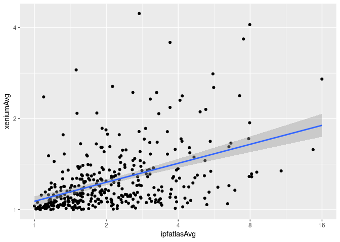

```r
ggplot(data=nonzeroaverages, aes(x=ipfatlasAvg, y=xeniumAvg)) +
  geom_point() +
  scale_x_continuous(trans='log2') +
  scale_y_continuous(trans='log2') +
  geom_smooth(method='lm', formula= y~x)
```

Probes with much lower Xenium average than we would expect based on expression.

```r
lm(xeniumAvg~ipfatlasAvg, data=nonzeroaverages)
```

```
##
## Call:
## lm(formula = xeniumAvg ~ ipfatlasAvg, data = nonzeroaverages)
##
## Coefficients:
## (Intercept)  ipfatlasAvg
##     1.05438      0.09528
```

Somewhat arbitrarily, let’s say something is somewhat lower expression than we would expect, that would not be great.

```r
folddiff <- 4
nonzeroaverages$shitlist1 <- unlist(lapply(nonzeroaverages$gene, function(symbol){
  expected <- (0.09528 /folddiff) * filter(nonzeroaverages,gene==symbol)$ipfatlasAvg + 1
  return(filter(nonzeroaverages,gene==symbol)$xeniumAvg < expected)
}))
```

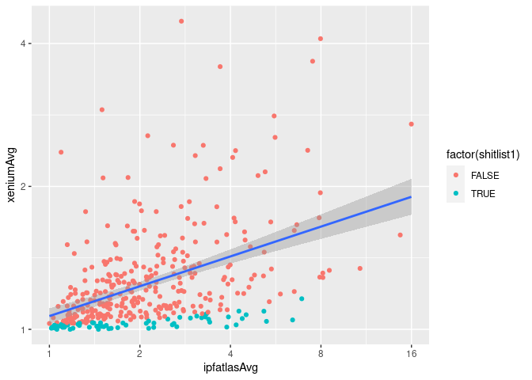

```r
ggplot(data=nonzeroaverages, aes(x=ipfatlasAvg, y=xeniumAvg)) +
  geom_point(aes(color=factor(shitlist1))) +
  scale_x_continuous(trans='log2') +
  scale_y_continuous(trans='log2') +
  geom_smooth(method='lm', formula= y~x)
```

```r
filter(nonzeroaverages, shitlist1)
```

```
##        gene xeniumAvg ipfatlasAvg shitlist1
## 1      ARG1  1.015317    1.109474      TRUE
## 2     ARL14  1.021099    1.150538      TRUE
## 3     ASCL1  1.012780    2.652174      TRUE
## 4     ASCL2  1.015446    1.108058      TRUE
## 5     ASCL3  1.011023    3.888889      TRUE
## 6     CCNA1  1.031630    1.403930      TRUE
## 7      CCR3  1.011628    1.107388      TRUE
## 8      CD1A  1.059944    2.714611      TRUE
## 9      CD1C  1.050812    2.476870      TRUE
## 10     CD70  1.000000    1.455546      TRUE
## 11     CD8B  1.032255    1.479127      TRUE
## 12   CDKN2A  1.019265    1.546578      TRUE
## 13    CLCA1  1.007246    1.023404      TRUE
## 14    CLDN4  1.057780    3.208881      TRUE
```

[output cut: 53 more lines]

## Zero-suppressed median expression

```r
nonzeromedians <- data.frame(gene=probes,
                              xeniumMed=unlist(future_lapply(probes, function(symbol){
                                counts <- ipf3.xen[['Xenium']]$counts[symbol,]
                                nonzeroavg <- median(counts[counts!=0])
                                return(nonzeroavg)
                                })),
                              ipfatlasMed=unlist(future_lapply(probes, function(symbol){
                                counts <- ipfatlas.cells[['RNA']]$counts[symbol,]
                                nonzeroavg <- median(counts[counts!=0])
                                return(nonzeroavg)
                              }))
)
```

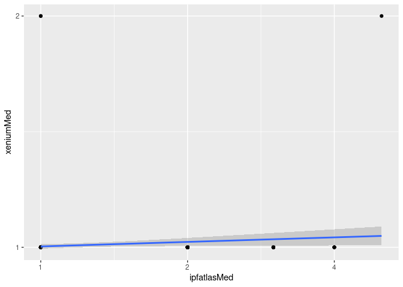

```r
ggplot(data=nonzeromedians, aes(x=ipfatlasMed, y=xeniumMed)) +
  geom_point() +
  scale_x_continuous(trans='log2') +
  scale_y_continuous(trans='log2') +
  geom_smooth(method='lm', formula= y~x)
```

## zero-suppressed top decile expression

```r
nonzerodecile <- data.frame(gene=probes,
                              xeniumDec=unlist(future_lapply(probes, function(symbol){
                                counts <- ipf3.xen[['Xenium']]$counts[symbol,]
                                nonzeroDec <- quantile(counts[counts!=0], probs=0.9)
                                return(nonzeroDec)
                                })),
                              ipfatlasDec=unlist(future_lapply(probes, function(symbol){
                                counts <- ipfatlas.cells[['RNA']]$counts[symbol,]
                                nonzeroDec <- quantile(counts[counts!=0], probs=0.9)
                                return(nonzeroDec)
                              }))
)
```

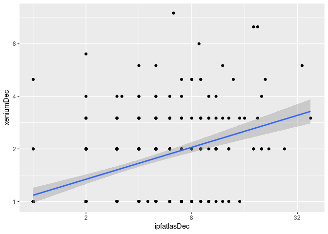

```r
ggplot(data=nonzerodecile, aes(x=ipfatlasDec, y=xeniumDec)) +
  geom_point() +
  scale_x_continuous(trans='log2') +
  scale_y_continuous(trans='log2') +
  geom_smooth(method='lm', formula= y~x)
```

# Comparison of normalized counts between scRNA and Xenium

This might better account for cells wtih low overall detection, and also has the advantage of being somewhat closer to what actual analysis might be like.

## Zero-suppressed average normalized expression

```r
nonzeroaverages$xeniumNormAvg <- unlist(future_lapply(probes, function(symbol){
  counts <- GetAssayData(object = ipf3.xen, slot = 'data')[symbol,]
  nonzeroavg <- mean(counts[counts>0])
  return(nonzeroavg)
}))
nonzeroaverages$ipfatlasNormAvg <- unlist(future_lapply(probes, function(symbol){
  counts <- GetAssayData(object = ipfatlas.cells, slot = 'data')[symbol,]
  nonzeroavg <- mean(counts[counts>0])
  return(nonzeroavg)
}))
```

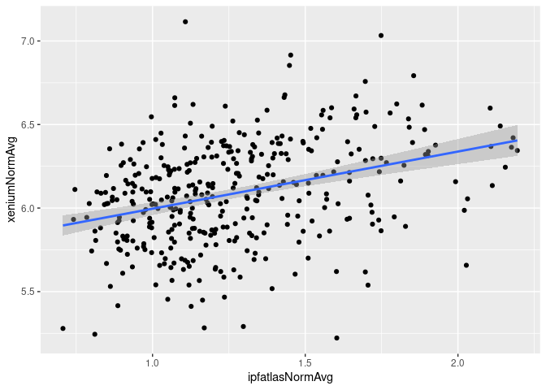

```r
ggplot(data=nonzeroaverages, aes(x=ipfatlasNormAvg, y=xeniumNormAvg)) +
  geom_point() +
  geom_smooth(method='lm', formula= y~x)
```

Probes with much lower Xenium average than we would expect based on expression.

```r
lm(xeniumNormAvg ~ ipfatlasNormAvg, data = nonzeroaverages)
```

```
##
## Call:
## lm(formula = xeniumNormAvg ~ ipfatlasNormAvg, data = nonzeroaverages)
##
## Coefficients:
##     (Intercept)  ipfatlasNormAvg
##          5.6541           0.3421
```

Somewhat arbitrarily, let’s say something is some-fold lower normalized expression than we would expect, that would not be great.

```r
logdiff <- .6
nonzeroaverages$shitlist2 <- unlist(lapply(nonzeroaverages$gene, function(symbol){
  expected <- 0.3421 * filter(nonzeroaverages,gene==symbol)$ipfatlasNormAvg + 5.6541 - logdiff
  return(filter(nonzeroaverages,gene==symbol)$xeniumNormAvg < expected)
}))
```

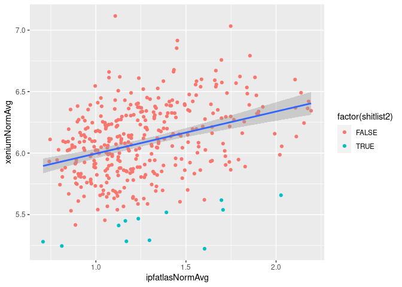

```r
ggplot(data=nonzeroaverages, aes(x=ipfatlasNormAvg, y=xeniumNormAvg)) +
  geom_point(aes(color=factor(shitlist2))) +
  geom_smooth(method='lm', formula= y~x)
```

```r
filter(nonzeroaverages, shitlist2)
```

```
##      gene xeniumAvg ipfatlasAvg shitlist1 xeniumNormAvg ipfatlasNormAvg
## 1   CLDN4  1.057780    3.208881      TRUE      5.290944       1.2973455
## 2    ELF3  1.340011    5.474371     FALSE      5.617571       1.6967458
## 3   FOXA2  1.057750    1.030303     FALSE      5.279343       0.7067073
## 4   GDF15  1.347594    2.820631     FALSE      5.282730       1.1693547
## 5  IL17RB  1.211359    1.218340     FALSE      5.244558       0.8110011
## 6    KLF5  1.297584    2.187218     FALSE      5.411537       1.1264546
## 7   MUC16  1.312336    2.259031     FALSE      5.448747       1.1636884
## 8   NCEH1  1.357214    3.026125     FALSE      5.517750       1.3914294
## 9    RBP4  1.077899    3.329302      TRUE      5.466767       1.2353999
## 10   RETN  1.092315    4.267827      TRUE      5.222207       1.6032702
## 11 S100A9  1.313681    8.113633     FALSE      5.657533       2.0274530
## 12  SFTA2  1.159972    6.907276      TRUE      5.538653       1.7055857
##    shitlist2
## 1       TRUE
## 2       TRUE
## 3       TRUE
## 4       TRUE
## 5       TRUE
## 6       TRUE
## 7       TRUE
## 8       TRUE
## 9       TRUE
## 10      TRUE
## 11      TRUE
## 12      TRUE
```

## Mix and match

SPARPOS is going to want to filter on norm avg expression. So does that clearly predict whether raw counts are found in Xenium?

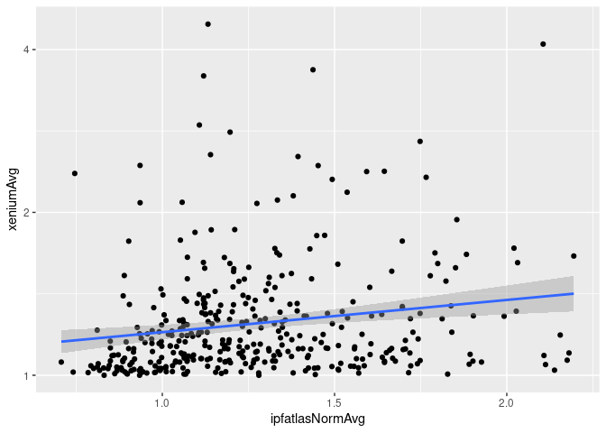

```r
ggplot(data=nonzeroaverages, aes(x=ipfatlasNormAvg, y=xeniumAvg)) +
  geom_point() +
  scale_y_continuous(trans='log2') +
  geom_smooth(method='lm', formula= y~x)
```

I think the answer is, sort of. But really the conclusion seems to be that there are high-performing probes that aren’t as sensitive to low expression, assuming they are specific.

```r
xenrawthreshold <- 1.5
nonzeroaverages$winner1 <- unlist(lapply(nonzeroaverages$gene, function(symbol){
  return(filter(nonzeroaverages,gene==symbol)$xeniumAvg > xenrawthreshold)
}))
```

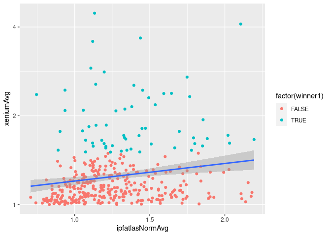

```r
ggplot(data=nonzeroaverages, aes(x=ipfatlasNormAvg, y=xeniumAvg)) +
  geom_point(aes(color=factor(winner1))) +
  scale_y_continuous(trans='log2') +
  geom_smooth(method='lm', formula= y~x)
```

```r
filter(nonzeroaverages, winner1)
```

```
##        gene xeniumAvg ipfatlasAvg shitlist1 xeniumNormAvg ipfatlasNormAvg
## 1     ABCA3  2.557023    2.123743     FALSE      6.083660       1.1400009
## 2      AGR2  1.684523    4.149697     FALSE      5.691972       1.3324659
## 3    ALOX15  1.577000    2.418057     FALSE      6.038317       1.1230962
## 4   ALOX15B  2.084026    1.508238     FALSE      5.803463       0.9355292
## 5     ANPEP  1.813767    2.743068     FALSE      6.141096       1.4712796
## 6      APOD  1.541977    4.475592     FALSE      6.585613       1.3748282
## 7      AREG  1.614811    6.522397     FALSE      6.055301       2.0313897
## 8    ATP1B1  1.573614    2.339155     FALSE      5.780670       1.2076023
## 9    CCDC78  1.528022    3.059291     FALSE      6.079279       1.3474054
## 10    CD163  1.858800    1.920827     FALSE      6.311918       1.2102073
## 11     CDH1  1.604368    4.456958     FALSE      5.700287       1.5095261
## 12  CEACAM6  1.715160    4.112094     FALSE      5.942191       1.3267291
## 13    CHIT1  3.669701    7.505662     FALSE      6.324976       1.4374753
## 14   COL1A1  2.705605   15.986456     FALSE      7.032845       1.7483165
```

[output cut: 107 more lines]